# Assemble POC, environmental and UVP data

Author

Thelma Panaïotis

## Load data

```r
source("utils.R")

load("data/01.uvp_profiles.Rdata")
load("data/02.carbon_data.Rdata")
load("data/03.all_env.Rdata")
rm(coast)
```

## Round coordinates of env and UVP data to match carbon data

- **Case 1: carbon data from Wang**

Carbon data is given on a 2°×2° grid, so we need to round env and UVP coordinates to match the same grid. Carbon longitudes are odd so we need to floor longitude with `precision = 2` and then add 1 to the result. Carbon latitudes are even so we can just round with `precision = 2`.

- **Case 2: carbon data from Argo floats**

- **Case 3: carbon data from Sauzède**

Carbon data is given on a 0.25°×0.25° grid, so we need to round UVP coordinates to match the same grid. We need to floor longitude with `precision = 0.25` and then add 0.125 to the result. We need to floor latitude with `precision = 0.25` and then add 0.125 to the result.

```r
# Choose C data source
#c_data <- "wang"
#c_data <- "argo"
c_data <- "canyon"
if (c_data == "wang") {
  df_c <- df_c_mod
} else  if (c_data == "argo"){
  df_c <- df_c_argo
} else {
  df_c <- df_c_can
}
```

### Env data

Ignore env data if using POC from Sauzède because it is computed from the environment.

```r
if (c_data == "wang") {

  env <- env %>%
    arrange(lon, lat) %>%
    rowwise() %>%
    mutate(
      # for wang, floor longitude and add 1 because carbon longitudes are odd
      lon = roundp(lon, precision = 2, f = floor) + 1,
      # for wang, round latitude because carbon latitudes are even
      lat = roundp(lat, precision = 2, f = round)
    ) %>%
    # Average all values on carbon pixels
    group_by(lon, lat) %>%
    summarise_all(mean, na.rm = TRUE) %>%
    ungroup()

} else  if (c_data == "argo"){

  env <- env %>%
    arrange(lon, lat) %>%
    rowwise() %>%
    mutate(
      # for argo, round to 8°
      lon = roundp(lon, precision = 8, f = round),
      # for argo, round to 4°
      lat = roundp(lat, precision = 8, f = round)
    ) %>%
    # Average all values on carbon pixels
    group_by(lon, lat) %>%
    summarise_all(mean, na.rm = TRUE) %>%
    ungroup()
}
```

### UVP data

We can start by plotting a map of UVP profiles.

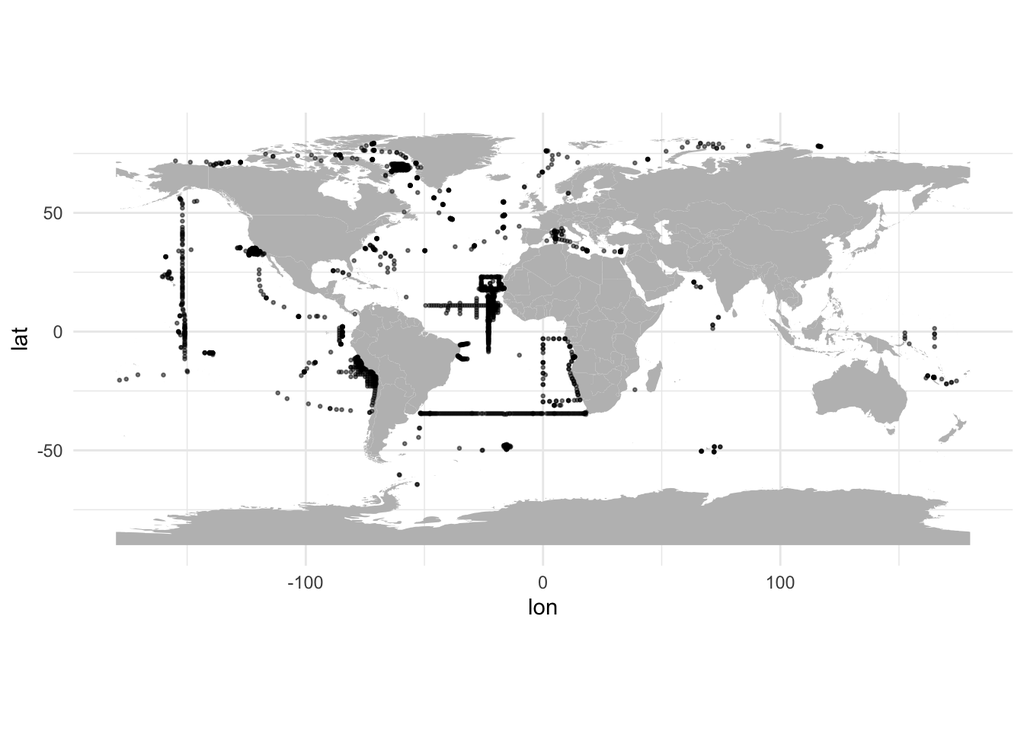

```r
profiles %>%
  ggplot() +
  geom_polygon(data = world, aes(x = lon, y = lat, group = group), fill = "gray") +
  geom_point(aes(x = lon, y = lat), alpha = 0.5, size = 0.5) +
  coord_quickmap()
```

Now let’s round the coordinates and replot the map. We also need to average UVP data on our new grid, but before that let’s also compute the number of UVP profiles per carbon pixel.

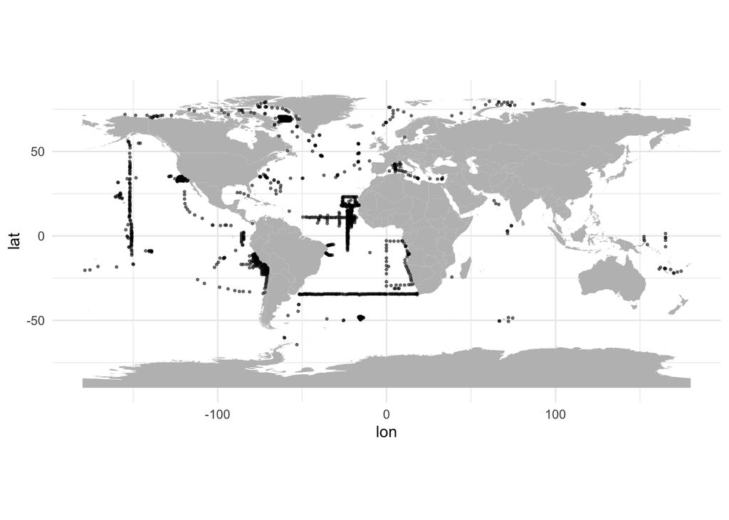

```r
if (c_data == "wang") {

  profiles_r <- profiles %>%
    # Drop profile identification
    select(-profile_id) %>%
    arrange(lon, lat) %>%
    rowwise() %>%
    mutate(
      # for wang, floor longitude and add 1 because carbon longitudes are odd
      lon = roundp(lon, precision = 2, f = floor) + 1,
      # for wang, round latitude because carbon latitudes are even
      lat = roundp(lat, precision = 2, f = round)
    ) %>%
    # Average all values on carbon pixels
    group_by(lon, lat) %>%
    summarise_all(mean, na.rm = TRUE) %>%
    ungroup()

} else  if (c_data == "argo"){

  profiles_r <- profiles %>%
    # Drop profile identification
    select(-profile_id) %>%
    arrange(lon, lat) %>%
    rowwise() %>%
    mutate(
      # for argo, round to 8°
      lon = roundp(lon, precision = 8, f = round),
      # for argo, round to 4°
      lat = roundp(lat, precision = 8, f = round)
    ) %>%
    # Average all values on carbon pixels
    group_by(lon, lat) %>%
    summarise_all(mean, na.rm = TRUE) %>%
    ungroup()

} else {

  profiles_r <- profiles %>%
    # Drop profile identification
    select(-profile_id) %>%
    arrange(lon, lat) %>%
    rowwise() %>%
    mutate(
      # for canyon, floor longitude at 0.25 and add 0.125
      lon = roundp(lon, precision = 0.25, f = floor) + 0.125,
      # for canyon, floor latitude at 0.25 and add 0.125
      lat = roundp(lat, precision = 0.25, f = floor) + 0.125
    ) %>%
    # Average all values on carbon pixels
    group_by(lon, lat) %>%
    summarise_all(mean, na.rm = TRUE) %>%
    ungroup()
}

n_profiles <- profiles_r %>% count(lon, lat)

profiles_r <- profiles_r %>%
  # Average all values on carbon pixels
  group_by(lon, lat) %>%
  summarise_all(mean, na.rm = TRUE) %>%
  ungroup()

profiles_r %>%
  ggplot() +
  geom_polygon(data = world, aes(x = lon, y = lat, group = group), fill = "gray") +
  geom_point(aes(x = lon, y = lat), alpha = 0.5, size = 0.5) +
  coord_quickmap()
```

UVP profiles are now aligned on the carbon grid. We can also plot the number of UVP profiles per pixel.

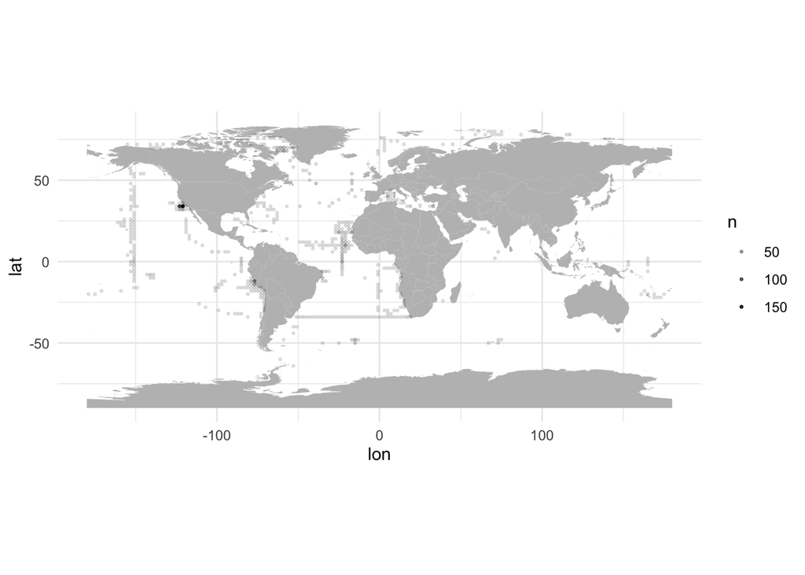

```r
n_profiles %>%
  ggplot() +
  geom_polygon(data = world, aes(x = lon, y = lat, group = group), fill = "gray") +
  geom_point(aes(x = lon, y = lat, alpha = n), size = 0.5) +
  coord_quickmap()
```

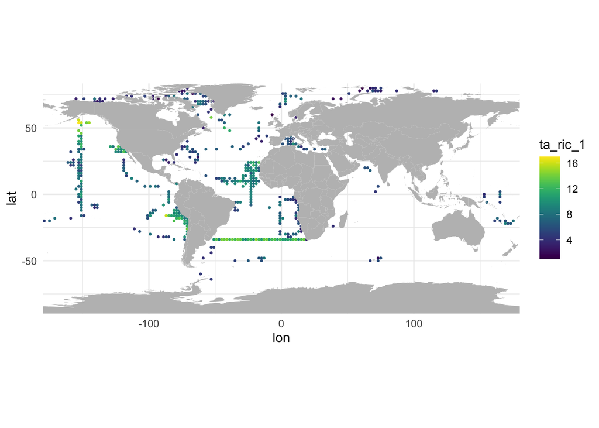

```r
ggmap(profiles_r, "ta_ric_1", type = "point")
```

## Assemble env, UVP and carbon data

Since all three datasets use the same round coordinates, we can join them together. As a result, we will only get env and carbon data where UVP data is available.

```r
if (c_data == "canyon"){
  # If we use C data from Sauzède, do not include env
  df <- profiles_r %>%
    left_join(df_c, by = join_by(lon, lat)) %>%
    select(lon, lat, everything())
} else {
  # Otherwise, include env
  df <- profiles_r %>%
    left_join(env,  by = join_by(lon, lat)) %>%
    left_join(df_c, by = join_by(lon, lat)) %>%
    select(lon, lat, everything())
}
```

Now, we can plot POC data at locations of UVP profiles.

[figure not shown]

```r
ggmap(df, "att", type = "point")
```

```r
#ggmap(df, "temperature", type = "point", palette = scale_colour_cmocean(name = "thermal"))
```

```r
summary(df)
```

```
      lon               lat            datetime         prop_crustacea
 Min.   :-179.00   Min.   :-64.00   Min.   :1.214e+09   Min.   :0.0000
 1st Qu.: -97.00   1st Qu.:-16.00   1st Qu.:1.332e+09   1st Qu.:0.3384
 Median : -47.00   Median : 12.00   Median :1.407e+09   Median :0.4848
 Mean   : -48.54   Mean   : 14.85   Mean   :1.395e+09   Mean   :0.5221
 3rd Qu.:  -1.00   3rd Qu.: 38.00   3rd Qu.:1.449e+09   3rd Qu.:0.7005
 Max.   : 175.00   Max.   : 80.00   Max.   :1.502e+09   Max.   :1.0000

 prop_rhizaria    prop_gelatinous   prop_mollusca        prop_other
 Min.   :0.0000   Min.   :0.00000   Min.   :0.000000   Min.   :0.00000
 1st Qu.:0.1715   1st Qu.:0.02497   1st Qu.:0.000000   1st Qu.:0.01652
 Median :0.3459   Median :0.05882   Median :0.000000   Median :0.04082
 Mean   :0.3392   Mean   :0.08484   Mean   :0.006126   Mean   :0.04769
 3rd Qu.:0.4971   3rd Qu.:0.10952   3rd Qu.:0.005560   3rd Qu.:0.06496
 Max.   :1.0000   Max.   :0.92308   Max.   :0.277391   Max.   :0.38462

     abund            biovol             ta_ric_1         ta_ric_2
 Min.   : 11.00   Min.   :    12.95   Min.   : 1.000   Min.   :0.000
 1st Qu.: 20.00   1st Qu.:   254.71   1st Qu.: 5.083   1st Qu.:1.304
 Median : 39.00   Median :   648.29   Median : 7.000   Median :1.842
 Mean   : 54.99   Mean   :  2469.75   Mean   : 7.530   Mean   :1.768
 3rd Qu.: 73.55   3rd Qu.:  1423.80   3rd Qu.: 9.286   3rd Qu.:2.222
 Max.   :543.57   Max.   :125561.22   Max.   :17.000   Max.   :3.413

    ta_ric_3         ta_div_1        ta_eve_1          ta_div_2
 Min.   :0.1386   Min.   :0.000   Min.   :0.06147   Min.   :0.0000
 1st Qu.:0.8980   1st Qu.:1.021   1st Qu.:0.60409   1st Qu.:0.8565
 Median :1.2186   Median :1.428   Median :0.70959   Median :1.1684
 Mean   :1.1975   Mean   :1.318   Mean   :0.68171   Mean   :1.0967
 3rd Qu.:1.4552   3rd Qu.:1.630   3rd Qu.:0.80057   3rd Qu.:1.3550
 Max.   :2.5000   Max.   :2.165   Max.   :0.96813   Max.   :1.9119

    ta_div_3          ta_eve_3         ta_mast            ss_slope
 Min.   :0.07576   Min.   :0.1413   Min.   :0.009907   Min.   :-4.7387
 1st Qu.:0.23507   1st Qu.:0.3454   1st Qu.:0.119833   1st Qu.:-2.7561
 Median :0.31679   Median :0.4541   Median :0.199015   Median :-2.5091
 Mean   :0.37268   Mean   :0.5260   Mean   :0.222313   Mean   :-2.4730
 3rd Qu.:0.46514   3rd Qu.:0.6400   3rd Qu.:0.292894   3rd Qu.:-2.1388
 Max.   :1.00000   Max.   :1.6500   Max.   :0.666667   Max.   :-0.8239

```

[output cut: 81 more lines]

```
 Min.   :  155.6   Min.   :  100.3   Min.   :  3.815   Min.   :0.01051
 1st Qu.: 1669.1   1st Qu.: 1094.9   1st Qu.: 39.225   1st Qu.:0.02042
 Median : 2283.2   Median : 1510.2   Median : 70.569   Median :0.02987
 Mean   : 2963.9   Mean   : 2002.3   Mean   :137.507   Mean   :0.05217
 3rd Qu.: 3512.2   3rd Qu.: 2366.4   3rd Qu.:204.710   3rd Qu.:0.04642
 Max.   :21513.7   Max.   :14537.9   Max.   :785.500   Max.   :0.20302
 NA's   :29        NA's   :29        NA's   :29        NA's   :29
      att
 Min.   :0.7970
 1st Qu.:0.9536
 Median :0.9701
 Mean   :0.9478
 3rd Qu.:0.9796
 Max.   :0.9895
 NA's   :29
```

Let’s get rid of these points.

```r
df <- df %>% drop_na()
```

We still have 405 points in our dataset.

Let’s redraw our POC map.

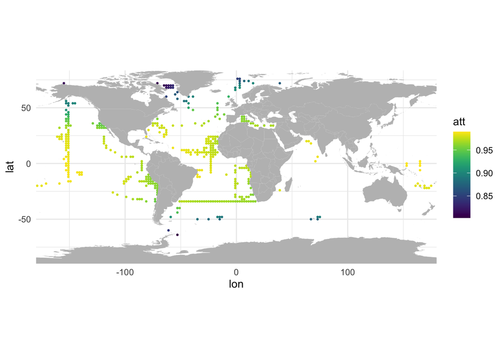

```r
ggmap(df, "att", type = "point")
```

## Save the resulting dataset

```r
save(df, file = file.path(data_dir, "04.all_data.Rdata"))
```